# Projections Onto Subspaces

Ferran Muiños and Ramon Massoni-Badosa

06/09/2020

# 1 Introduction and objectives

In this hands-on session, we will review the concept of projections onto vector subspaces. Specifically, we aim to achieve the following objectives:

1. Use orthogonal projections to solve general systems of linear equations of the form Ax = b when b is not necessarily in the column space of A.
2. Understand this problem both algebraically and geometrically. For the latter we will use the power of [Shiny apps](https://shiny.rstudio.com/).
3. Find the least squares regression solution line for n points in R<sup>2</sup> using the concepts explained in this session. Least squares is a real-world, pervasive application of linear algebra.
4. Learn to use [ggplot2](https://ggplot2.tidyverse.org/) to obtain publication-quality graphics.

# 2 Disclaimer

This hands-on session comprises some challenging concepts. We believe that all the students at your level are able to grasp them with time and dedication, but it would also be within the expected if you don’t finish this document or don’t understand everything in the classroom. You will have this document for you to study after the class, and we will be available to answer any questions.

# 3 Description of the problem

We want to find a suitable solution for a system of linear equations Ax = b that has no proper, exact solution in the traditional sense. We can approach this problem from two different perspectives, which master Gilbert Strang refer to as the “row and column pictures” of a system of equations.

## 3.1 Row picture

Let us illustrate the problem with the following system of equations:

$$\begin{cases} x+0y=6\\x+y=0\\x+2y=0 \end{cases}$$

Which can be represented in matrix form as Ax = b:

$$Ax = b$$

$$\begin{bmatrix}1&0 \\1&1 \\1&2 \\\end{bmatrix} \begin{bmatrix}x \\y \\\end{bmatrix} = \begin{bmatrix}6 \\0 \\0 \\\end{bmatrix}$$

Where A is the **coefficient matrix**, x is the vector that contains the **unknowns** and b is the vector that contains the **constants**. Geometrically, the row picture tells us that a system of linear equations has no solution if all the lines specified by the equations do not meet in a single point:

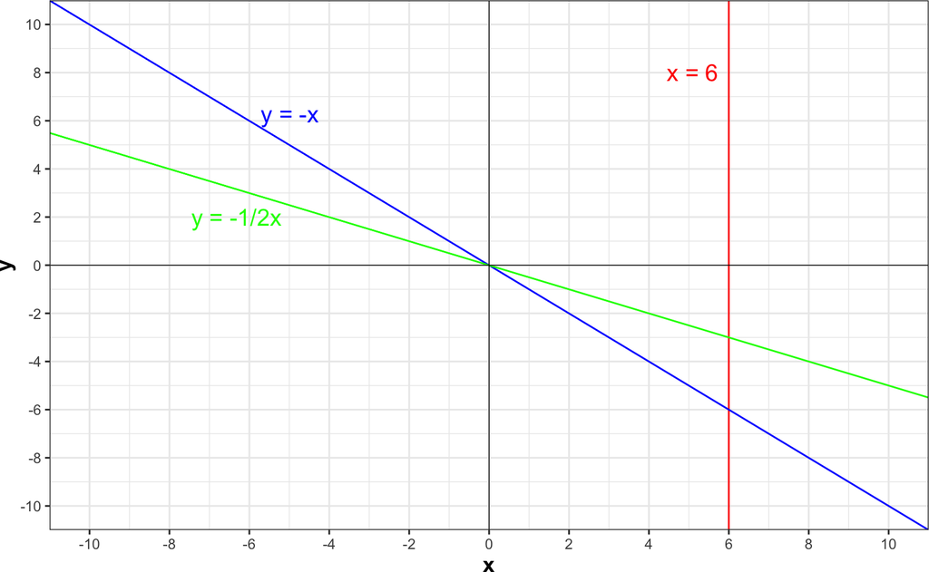

This is typically the case in **systems of linear equations with more equations than unknowns**. We can think of these as systems with “tall and skinny matrices” (more rows than columns).

The term “row picture” is reminiscent of the fact that each row of the system represents an equation, and every linear equation in the plane has typically not just one but many –a straight line of– solutions.

## 3.2 Column picture

Understanding Ax = b using the column picture is the ultimate goal of linear algebra. We do not think of equations and unknowns anymore. Instead, we interpret the elements of this problem as follows:

- The matrix A specifies two column vectors (a<sub>1</sub> and a<sub>2</sub>). All the possible linear combinations of a<sub>1</sub> and a<sub>2</sub> (their span) are collectively known as the column space of A, or C(A).
- The elements of x (x<sub>1</sub> and x<sub>2</sub> hereafter) specify which linear combination of a1 and a2 to take. * b specifies the result of a specific choice of x.

The algebraic interpretation of the column picture of the previous example is the following:

$$Ax = b$$

$$\begin{bmatrix}1&0 \\1&1 \\1&2 \\\end{bmatrix} \begin{bmatrix}x1 \\x2 \\\end{bmatrix} = \begin{bmatrix}6 \\0 \\0 \\\end{bmatrix}$$

$$x1 \begin{bmatrix}1 \\1 \\1 \\\end{bmatrix} + x2 \begin{bmatrix}0 \\1 \\2 \\\end{bmatrix} = \begin{bmatrix}6 \\0 \\0 \\\end{bmatrix}$$
Thus, Ax = b has no proper solution in the traditional sense whenever b is not contained in C(A). In other words, there is no two x<sub>1</sub> and x<sub>2</sub> that specify a linear combination of a<sub>1</sub> and a<sub>2</sub> that produces b.

**Exercise** To geometrically visualize this, enter to the shiny app associated with this tutorial by clicking the following link or copying it into your browser:

https://massonix.shinyapps.io/projections_onto_subspaces/

Then, in the left hand side of the app enter the matrix A and the vector b. The app will render a visualization of C(A) as a plane in R<sup>3</sup>, and b as a vector in R<sup>3</sup>, which need not be contained in the plane.

# 4 Solving the problem

As we have seen above, there is in general no vector x that will provide a proper solution of Ax = b in the traditional sense. However, we can provide “the best solution we can” by finding the vector p = $\widehat{x}$<sub>1</sub> a<sub>1</sub> + ··· + $\widehat{x}$<sub>n</sub> a<sub>n</sub> that is **as close as possible to the vector b**. To make the “as close as possible” more precise, we will consider the closest vector to b that cuts the column space C(A) by moving perpendicularly with respect to C(A), i.e., **p** will be the orthogonal projection of **b** onto C(A). You can clearly visualize this in the shiny app.

As p is in C(A), we can find a vector $\widehat{x}$ that solves the new system: A$\widehat{x}$ = p.

We will analyze this problem in three steps, which are highlighted in the section “Projection Onto a Subspace” in Chapter 4 of “Introduction to Linear Algebra”, by Gilbert Strang. The steps are the following:

1. Find the vector $\widehat{x}$.

We will develop each of the steps and apply them to solve the example above.

## 4.1 Find x^

The key to find $\widehat{x}$ is in the geometry of the error vector e, defined as follows:

$$e = b - p = b - A\widehat{x}$$
As you can see in the app, e is orthogonal to C(A). Thus, **the scalar product of each column vector of A (a<sub>1</sub>,···, a<sub>n</sub>) and e is 0**. We can express this as a single matrix-vector product by transposing A, so that the column vectors become the rows of A<sup>T</sup>:

$$A^T e = 0$$
Replacing e by its definition:

$$A^T (b - A\widehat{x}) = 0$$

Let us distribute A<sup>T</sup>:

$$A^Tb - A^T A\widehat{x} = 0$$

And add $A^T A\widehat{x}$ to both sides:

$$A^Tb = A^T A\widehat{x}$$

We know that the symmetric matrix A<sup>T</sup>A is invertible if the column vectors are independent. If that’s the case, we can multiply both sides by (A<sup>T</sup>A)<sup>-1</sup> and isolate $\widehat{x}$:

$$(A^T A)^{-1} A^Tb = (A^T A)^{-1} A^T A\widehat{x}$$
$$(A^T A)^{-1} A^Tb = \textrm{Id}\; \widehat{x} = \widehat{x}$$

$$\widehat{x} = (A^T A)^{-1} A^Tb$$

Let us apply this formula to the example above. To make computations easier, we will use the operations in R that we learned in the previous hands-on session. First, we compute A<sup>T</sup>A:

```r
A <- matrix(c(1, 1, 1, 0, 1, 2), nrow = 3, ncol = 2, byrow = FALSE)
AT_A <- t(A) %*% A
AT_A
```

```
##      [,1] [,2]
## [1,]    3    3
## [2,]    3    5
```

$$A^TA = \begin{bmatrix}1&1&1 \\0&1&2 \\\end{bmatrix} \begin{bmatrix}1&0 \\1&1 \\1&2 \\\end{bmatrix} = \begin{bmatrix}3&3 \\3&5 \\\end{bmatrix}$$

Now we find the inverse $(A^T A)^{-1}$:

```r
library(matlib)
library(MASS)
AT_A_inv <- inv(AT_A)
AT_A_inv <- fractions(AT_A_inv)
AT_A_inv
```

```
##      [,1] [,2]
## [1,]  5/6 -1/2
## [2,] -1/2  1/2
```

$$(A^T A)^{-1} = \begin{bmatrix}
5/6 & -1/2\\
-1/2 & 1/2
\end{bmatrix}$$

Finally, we can solve for $\widehat{x} = (A^T A)^{-1} A^Tb$:

```r
b <- matrix(c(6, 0, 0), nrow = 3)
x_hat <- AT_A_inv %*% t(A) %*% b
x_hat
```

```
##      [,1]
## [1,]    5
## [2,]   -3
```

$$\widehat{x} = (A^T A)^{-1} A^Tb = \begin{bmatrix} 5/6 & -1/2\\ -1/2 & 1/2 \end{bmatrix} \begin{bmatrix}1&1&1 \\0&1&2 \\\end{bmatrix} \begin{bmatrix}6 \\0 \\0 \\\end{bmatrix} = \begin{bmatrix} 5 \\ -3 \end{bmatrix}$$

**Note**: if you try to solve it by pencil and paper I would suggest starting at equation $A^Tb = A^T A\widehat{x}$, so you do not need to find an inverse.

## 4.2 Find p

Let us find p, which remember that is the projection of b onto C(A):

$$p = A \widehat{x} = A (A^T A)^{-1} A^Tb$$

```r
p <- A %*% x_hat
p
```

```
##      [,1]
## [1,]    5
## [2,]    2
## [3,]   -1
```

$$p = \begin{bmatrix}1&0 \\1&1 \\1&2 \\\end{bmatrix} \begin{bmatrix}4.99999998 \\-3 \\\end{bmatrix} = \begin{bmatrix}4.99999998 \\1.99999998 \\-1.00000002 \\\end{bmatrix}$$

## 4.3 Find the projection matrix P (optional)

Now we can pursue one more step to find the matrix P encoding the orthogonal projection onto the column space C(A), which describes a linear transformation that takes any vector and projects in onto C(A). If we look at what happened with b, it is easy to spot the matrix that did the job: $P = A (A^T A)^{-1} A^T$.

Projection matrices have two interesting properties:

1. It’s symmetric

$$P^T = P$$

2. If you square it you get P

$$P^2 = P$$

Can you guess why? Hint: Think about what happens if you project the vector p again onto C(A)

# 5 Introduction to ggplot2

Here, we will teach a basic skill that was not taught in our year and we find essential: high-quality graphics with ggplot2. Before, we need to explain the basics of tidy data, which is the input to ggplot2:

1. Observations are rows
2. Variables are columns
3. Observational units form a table

Moreover, ggplot2 is built based on *the grammar of graphics* philosophy. Thus, we should spend a few minutes introducing it.

Finally, to give a quick example of ggplot2 plotting, we can reproduce the gapminder scatterplot, which correlates life expectancy and GDP for each country:

```r
# Plot gapminder data, including a regression line in the scatter plot
library(tidyverse)
gapminder::gapminder %>%
  head()
```

```
## # A tibble: 6 x 6
##   country     continent  year lifeExp      pop gdpPercap
##   <fct>       <fct>     <int>   <dbl>    <int>     <dbl>
## 1 Afghanistan Asia       1952    28.8  8425333      779.
## 2 Afghanistan Asia       1957    30.3  9240934      821.
## 3 Afghanistan Asia       1962    32.0 10267083      853.
## 4 Afghanistan Asia       1967    34.0 11537966      836.
## 5 Afghanistan Asia       1972    36.1 13079460      740.
## 6 Afghanistan Asia       1977    38.4 14880372      786.
```

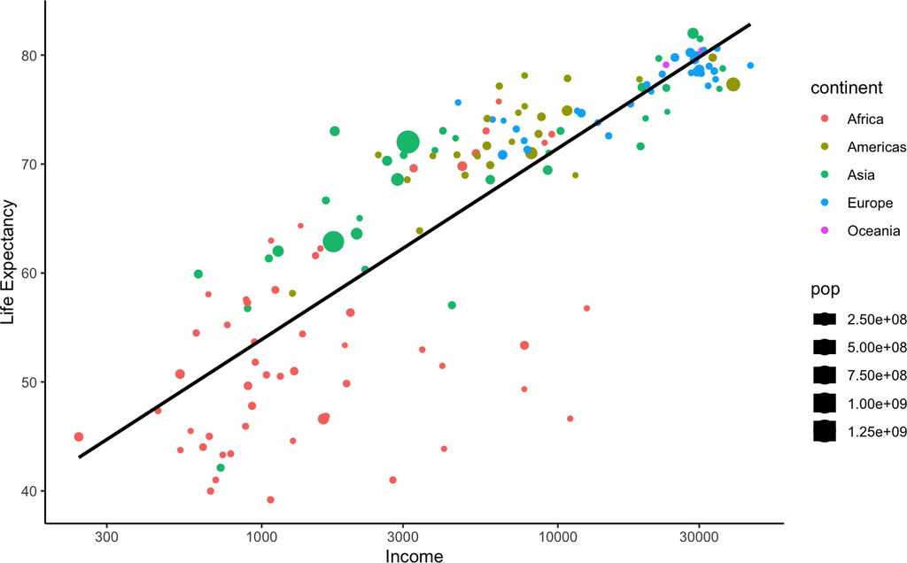

```r
# Filter to 2002
gapminder_2002 <- gapminder::gapminder[gapminder::gapminder$year == 2002, ]
gapminder_2002 %>%
  ggplot(aes(gdpPercap, lifeExp, color = continent, size = pop)) +
    geom_point() +
    geom_smooth(method = "lm", se = FALSE, color = "black") +
    scale_x_log10() +
    labs(x = "Income", y = "Life Expectancy") +
    theme_classic()
```

```r
# Actually fit the regression model
lm_model <- lm(lifeExp ~ log10(gdpPercap), data = gapminder::gapminder)
slope <- lm_model$coefficients[2]
y_intercept <- lm_model$coefficients[1]
print(slope)
```

```
## log10(gdpPercap)
##         19.35342
```

```r
print(y_intercept)
```

```
## (Intercept)
##   -9.100889
```

# 6 Least Squares exercise

Here is the problem that you should solve using the tools that we have seen until now:

1. Find the slope and the y-intercept of the least squares regression line between Life Expectancy ~ Income from the gapminder dataset.
2. Plot the regression line defining manually the parameters calculated in (1) and check that they are the same.

Hereafter, we will develop the reasoning and solution for this exercise. You are all highly encouraged to try the problem on your own and then compare the results. Otherwise, you can follow our explanation, and try to code each chunk by yourself before looking at ours.

First, we will subset the dataframe to keep only the variables of interest (life expectancy, income and country). Then we will visualize the first 3 rows with the `head()` function

```r
# Visualize the structure of the dataframe
str(gapminder::gapminder)
```

```
## tibble [1,704 × 6] (S3: tbl_df/tbl/data.frame)
##  $ country  : Factor w/ 142 levels "Afghanistan",..: 1 1 1 1 1 1 1 1 1 1 ...
##  $ continent: Factor w/ 5 levels "Africa","Americas",..: 3 3 3 3 3 3 3 3 3 3 ...
##  $ year     : int [1:1704] 1952 1957 1962 1967 1972 1977 1982 1987 1992 1997 ...
##  $ lifeExp  : num [1:1704] 28.8 30.3 32 34 36.1 ...
##  $ pop      : int [1:1704] 8425333 9240934 10267083 11537966 13079460 14880372 12881816 13867957 16317921 22227415 ...
##  $ gdpPercap: num [1:1704] 779 821 853 836 740 ...
```

```r
# Character subsetting
gapminder_sub <- gapminder_2002[, c("country", "lifeExp", "gdpPercap")]
head(gapminder_sub, 3)
```

```
## # A tibble: 3 x 3
##   country     lifeExp gdpPercap
##   <fct>         <dbl>     <dbl>
## 1 Afghanistan    42.1      727.
## 2 Albania        75.7     4604.
## 3 Algeria        71.0     5288.
```

Note that the gdpPercap in the previous scatter plot is in logarithmic scale. Let us log-transform it:

```r
gapminder_sub$log10_gdpPercap <- log10(gapminder_sub$gdpPercap)
head(gapminder_sub, 3)
```

```
## # A tibble: 3 x 4
##   country     lifeExp gdpPercap log10_gdpPercap
##   <fct>         <dbl>     <dbl>           <dbl>
## 1 Afghanistan    42.1      727.            2.86
## 2 Albania        75.7     4604.            3.66
## 3 Algeria        71.0     5288.            3.72
```

In our real problem, we have 142 equations for only two unknowns (slope and y-intercept). Thus, the coefficient matrix is 142x2. As you will have guessed, to find the least squares regression line we will need to use orthogonal projections to find m and n.

**Challenge**: To get a sense of how b, p and e translate in the context of a least squares problem try the shiny app.

To solve for m an n, we will first create the matrix A and the vector b. Note that the first column of A is the gdpPercap, and the vector b is the lifeExp:

```r
num_rows <- nrow(gapminder_sub)
A <- matrix(
  c(gapminder_sub$log10_gdpPercap, rep(1, num_rows)),
  nrow = num_rows,
  ncol = 2,
  byrow = FALSE
)
head(A)
```

```
##          [,1] [,2]
## [1,] 2.861376    1
## [2,] 3.663155    1
## [3,] 3.723295    1
## [4,] 3.442995    1
## [5,] 3.944366    1
## [6,] 4.486965    1
```

```r
b <- as.matrix(gapminder_sub$lifeExp)
head(b)
```

```
##        [,1]
## [1,] 42.129
## [2,] 75.651
## [3,] 70.994
## [4,] 41.003
## [5,] 74.340
## [6,] 80.370
```

We can solve the problem with the following equation (seen above):

$$\widehat{x} = (A^T A)^{-1} A^Tb$$

```r
AT_A <- t(A) %*% A
AT_A_inv <- inv(AT_A)
AT_A_inv <- AT_A_inv
x_hat <- AT_A_inv %*% t(A) %*% b
m <- x_hat[1, 1]
n <- x_hat[2, 1]
out <- str_c("The slope is ", round(m, 4), " and the y-intercept is ", round(n, 4))
print(out)
```

```
## [1] "The slope is 17.5394 and the y-intercept is 1.2807"
```

Finally, we can recreate the plot. This time, you should manually provide *m* and *n* that you calculated by yourselves.

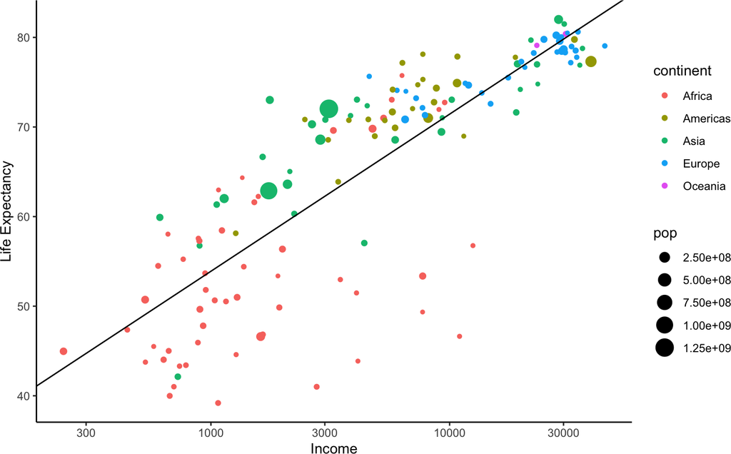

```r
gapminder_2002 %>%
  ggplot(aes(gdpPercap, lifeExp, color = continent, size = pop)) +
    geom_point() +
    geom_abline(slope = m, intercept = n, color = "black") +
    scale_x_log10() +
    labs(x = "Income", y = "Life Expectancy") +
    theme_classic()
```